# DADA2 ASV table generation from 16S rRNA gene sequences of DNA from Oman samples collected in 2014

## 5.3 Check if primers were removed by filterAndTrim

Generate sorted file name vector for filtered files

```r
fnFs_filt <- sort(list.files(filtpathF, full.names = TRUE))

# print first 6 lines
fnFs_filt %>% head()
```

```
## [1] "/Users/melo.d/Desktop/Research/Oman_fieldwork/Samail_16S_compilation_fq_outputs/2014/02_filter/preprocessed_F/filtered/NSHQ14_2014_S1_L001_R1_001.fastq.gz"
## [2] "/Users/melo.d/Desktop/Research/Oman_fieldwork/Samail_16S_compilation_fq_outputs/2014/02_filter/preprocessed_F/filtered/NSHQ4_2014_S2_L001_R1_001.fastq.gz"
```

```r
fnRs_filt <- sort(list.files(filtpathR, full.names = TRUE))
```

```r
# print file name
print(paste("file_name: ", basename(fnFs_filt[[1]])))
```

```
## [1] "file_name:  NSHQ14_2014_S1_L001_R1_001.fastq.gz"
```

```r
print(paste("total reads:", countLines(fnFs_filt[[1]])/4))
```

```
## [1] "total reads: 20794"
```

```r
# tally primer hits in file
rbind(FWD.ForwardReads = sapply(FWD.orients, primerHits, fn=fnFs_filt[[1]]),
      FWD.ReverseReads = sapply(FWD.orients, primerHits, fn=fnFs_filt[[1]]),
      REV.ForwardReads = sapply(REV.orients, primerHits, fn=fnFs_filt[[1]]),
      REV.ReverseReads = sapply(REV.orients, primerHits, fn=fnFs_filt[[1]]))
```

```
##                  Forward Complement Reverse RevComp
## FWD.ForwardReads       0          0       0       0
## FWD.ReverseReads       0          0       0       0
## REV.ForwardReads       0          0       0       1
## REV.ReverseReads       0          0       0       1
```

```r
# print file name
print(paste("file_name: ", basename(fnFs_filt[[2]])))
```

```
## [1] "file_name:  NSHQ4_2014_S2_L001_R1_001.fastq.gz"
```

```r
print(paste("total reads:", countLines(fnFs_filt[[2]])/4))
```

```
## [1] "total reads: 37456"
```

```r
# tally primer hits in file
rbind(FWD.ForwardReads = sapply(FWD.orients, primerHits, fn=fnFs_filt[[2]]),
      FWD.ReverseReads = sapply(FWD.orients, primerHits, fn=fnFs_filt[[2]]),
      REV.ForwardReads = sapply(REV.orients, primerHits, fn=fnFs_filt[[2]]),
      REV.ReverseReads = sapply(REV.orients, primerHits, fn=fnFs_filt[[2]]))
```

```
##                  Forward Complement Reverse RevComp
## FWD.ForwardReads       0          0       0       0
## FWD.ReverseReads       0          0       0       0
## REV.ForwardReads       0          0       0       0
## REV.ReverseReads       0          0       0       0
```

## 5.4 Plot the quality of the filtered and cut fastq files.

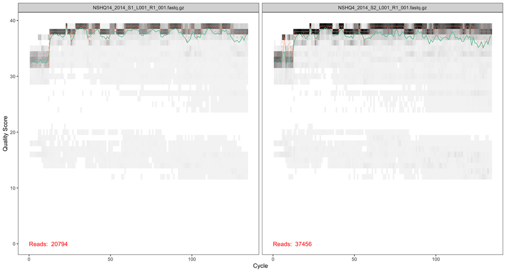

```r
# Forward reads
# If the number of samples is 20 or less, plot them all, otherwise, just plot 20 randomly selected samples
if( length(fnFs_filt) <= 20) {
  plotQualityProfile(fnFs_filt)
} else {
  rand_samples <- sample(size = 20, 1:length(fnFs_filt)) # grab 20 random samples to plot
  plotQualityProfile(fnFs_filt[rand_samples])
}
```

[figure not shown]

```r
# Forward reads
# If the number of samples is 20 or less, plot them all, otherwise, just plot 20 randomly selected samples
if( length(fnFs_filt) <= 20) {
  plotQualityProfile(fnFs_filt)
} else {
  rand_samples <- sample(size = 20, 1:length(fnFs_filt)) # grab 20 random samples to plot
  plotQualityProfile(fnFs_filt[rand_samples])
}
```

# 6 Infer sequence variants

In this part of the pipeline, dada2 will learn to distinguish error from biological differences using a subset of our data as a training set. After it understands the error rates, we will reduce the size of the dataset by combining all identical sequence reads into “unique sequences”. Then, using the dereplicated data and error rates, dada2 will infer the sequence variants in our data. Finally, we will merge the corresponding forward and reverse reads to create a list of the fully denoised sequences and create a sequence table from the result.

## 6.1 Learn the error rates

```r
set.seed(100) # set seed to ensure that randomized steps are reproducible

# Learn forward error rates
errF <- learnErrors(fnFs_filt, nbases=1e8, multithread=TRUE)
```

```
## 7805500 total bases in 58250 reads from 2 samples will be used for learning the error rates.
```

```r
# Learn reverse error rates
errR <- learnErrors(fnRs_filt, nbases=1e8, multithread=TRUE)
```

```
## 8621000 total bases in 58250 reads from 2 samples will be used for learning the error rates.
```

### 6.1.1 Plot Error Rates

The error rates for each possible transition (A→C, A→G, …) are shown. Points are the observed error rates for each consensus quality score. The black line shows the estimated error rates after convergence of the machine-learning algorithm. The red line shows the error rates expected under the nominal definition of the Q-score. Here, we want to see estimated error rates (black line) that are a good fit to the observed rates (points), and that the error rates drop with increased quality as expected. If these criteria aren’t observed, then it may be a good idea to increase the `nbases` parameter. This allows the machine learning algorithm to train on a larger portion of your data and may help improve the fit.

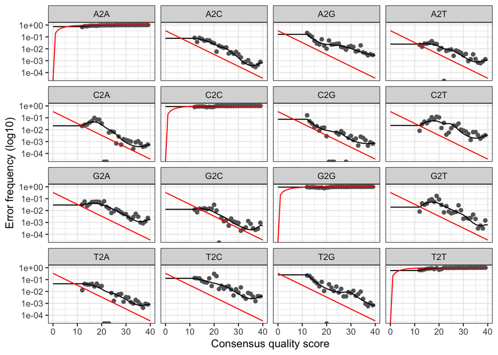

```r
plotErrors(errF, nominalQ=TRUE)
```

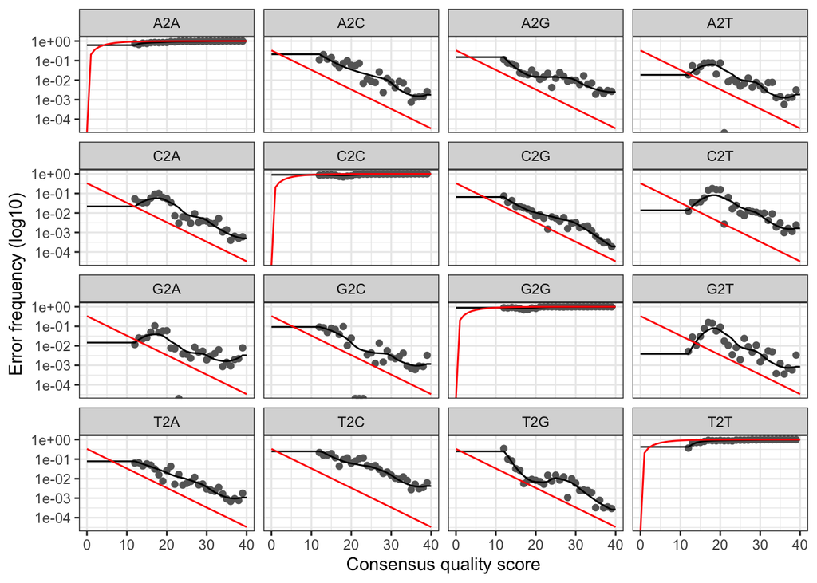

```r
plotErrors(errR, nominalQ=TRUE)
```

## 6.2 Dereplication, sequence inference, and merging of paired-end reads

Extract sample names and add them to vector of filtered file names

```r
# Extract sample names, assuming filenames have format: SAMPLENAME_XXX.fastq
sample_names_F_filt <- fnFs_filt %>% basename() %>% str_remove(pattern = "_S([[:digit:]]+)_L001_R1_001.fastq.gz")
sample_names_R_filt <- fnRs_filt %>% basename() %>% str_remove(pattern = "_S([[:digit:]]+)_L001_R2_001.fastq.gz")

# Double check
if(!identical(sample_names_F_filt, sample_names_R_filt)) stop("Forward and reverse files do not match.")

names(fnFs_filt) <- sample_names_F_filt
names(fnRs_filt) <- sample_names_R_filt
```

```r
# make lists to hold the loop output
mergers <- vector("list", length(sample_names_F))
names(mergers) <- sample_names_F
ddF <- vector("list", length(sample_names_F))
names(ddF) <- sample_names_F
ddR <- vector("list", length(sample_names_F))
names(ddR) <- sample_names_F

# For each sample, get a list of merged and denoised sequences
for(sam in sample_names_F) {
    cat("Processing:", sam, "\n")
    # Dereplicate forward reads
    derepF <- derepFastq(fnFs_filt[[sam]])
    # Infer sequences for forward reads
    ddF[[sam]] <- dada(derepF, err=errF, multithread=TRUE)
    # Dereplicate reverse reads
    derepR <- derepFastq(fnRs_filt[[sam]])
    # Infer sequences for reverse reads
    ddR[[sam]] <- dada(derepR, err=errR, multithread=TRUE)
    # Merge reads together
    merger <- mergePairs(ddF[[sam]], derepF, ddR[[sam]], derepR)
    mergers[[sam]] <- merger
}
```

```
## Processing: NSHQ14_2014
## Sample 1 - 20794 reads in 2450 unique sequences.
## Sample 1 - 20794 reads in 7078 unique sequences.
## Processing: NSHQ4_2014
## Sample 1 - 37456 reads in 7620 unique sequences.
## Sample 1 - 37456 reads in 15049 unique sequences.
```

```r
rm(derepF); rm(derepR)
```

## 6.3 Construct sequence table

```r
seqtab <- makeSequenceTable(mergers)
```

```r
write_rds(seqtab, path = format(Sys.Date(), "data_output/seqtab_OM14_processed_%Y%m%d.rds"), compress = "gz")
```

# 7 Remove Chimeras

Although dada2 has searched for insertion/deletion errors and substitutions, there may still be chimeric sequences in our dataset (sequences that are derived from forward and reverse sequences from two different organisms becoming fused together during PCR and/or sequencing). To identify chimeras, we will search for rare sequence variants that can be reconstructed by combining left-hand and right-hand segments from two more abundant “parent” sequences.

```r
# Remove chimeras
seqtab_nochim <- removeBimeraDenovo(seqtab, method="consensus", multithread=TRUE)
```

```r
# Print percentage of our sequences that were not chimeric.
100*sum(seqtab_nochim)/sum(seqtab)
```

```
## [1] 97.69407
```

```r
write_rds(seqtab_nochim, path = format(Sys.Date(), "data_output/seqtab_nochim_OM14_processed_%Y%m%d.rds"), compress = "gz")
```

# 8 Track reads through pipeline

```r
getN <- function(x) sum(getUniques(x)) # function to grab sequence counts from output objects
# tracking reads by counts
filt_out_track <- filt_out %>%
  data.frame() %>%
  mutate(Sample = rownames(.) %>% str_remove(pattern = "_S([[:digit:]]+)_L001_R1_001.fastq.gz")) %>%
  rename(input = reads.in, filtered = reads.out)
rownames(filt_out_track) <- filt_out_track$Sample

ddF_track <- data.frame(denoisedF = sapply(ddF[sample_names_F_filt], getN)) %>%
  mutate(Sample = row.names(.))
ddR_track <- data.frame(denoisedR = sapply(ddR[sample_names_F_filt], getN)) %>%
  mutate(Sample = row.names(.))
merge_track <- data.frame(merged = sapply(mergers, getN)) %>%
  mutate(Sample = row.names(.))
chim_track <- data.frame(nonchim = rowSums(seqtab_nochim)) %>%
  mutate(Sample = row.names(.))

track <- left_join(filt_out_track, ddF_track, by = "Sample") %>%
  # left_join(ddF_track, by = "Sample") %>%
  left_join(ddR_track, by = "Sample") %>%
  left_join(merge_track, by = "Sample") %>%
  left_join(chim_track, by = "Sample") %>%
  replace(., is.na(.), 0) %>%
  select(Sample, everything())
row.names(track) <- track$Sample
head(track)
```

|  | Sample | input | filtered | denoisedF | denoisedR | merged | nonchim |
| --- | --- | --- | --- | --- | --- | --- | --- |
| NSHQ14_2014 | NSHQ14_2014 | 25000 | 20794 | 20659 | 20343 | 20158 | 19438 |
| NSHQ4_2014 | NSHQ4_2014 | 45056 | 37456 | 36997 | 36270 | 34744 | 34198 |

```r
# tracking reads by percentage
track_pct <- track %>%
  data.frame() %>%
  mutate(Sample = rownames(.),
         filtered_pct = ifelse(filtered == 0, 0, 100 * (filtered/input)),
          # cut_pct = ifelse(cut == 0, 0, 100 * (cut/filtered)),
         denoisedF_pct = ifelse(denoisedF == 0, 0, 100 * (denoisedF/filtered)),
         denoisedR_pct = ifelse(denoisedR == 0, 0, 100 * (denoisedR/filtered)),
         merged_pct = ifelse(merged == 0, 0, 100 * merged/((denoisedF + denoisedR)/2)),
         nonchim_pct = ifelse(nonchim == 0, 0, 100 * (nonchim/merged)),
         total_pct = ifelse(nonchim == 0, 0, 100 * nonchim/input)) %>%
  select(Sample, ends_with("_pct"))

# summary stats of tracked reads averaged across samples
track_pct_avg <- track_pct %>% summarize_at(vars(ends_with("_pct")),
                                            list(avg = mean))
head(track_pct_avg)
```

|  | filtered_pct_avg | denoisedF_pct_avg | denoisedR_pct_avg | merged_pct_avg | nonchim_pct_avg | total_pct_avg |
| --- | --- | --- | --- | --- | --- | --- |
| 1 | 83.15405 | 99.06267 | 97.33236 | 96.58453 | 97.42836 | 76.82655 |

```r
track_pct_med <- track_pct %>% summarize_at(vars(ends_with("_pct")),
                                            list(avg = stats::median))
head(track_pct_avg)
```

|  | filtered_pct_avg | denoisedF_pct_avg | denoisedR_pct_avg | merged_pct_avg | nonchim_pct_avg | total_pct_avg |
| --- | --- | --- | --- | --- | --- | --- |
| 1 | 83.15405 | 99.06267 | 97.33236 | 96.58453 | 97.42836 | 76.82655 |

```r
head(track_pct_med)
```

|  | filtered_pct_avg | denoisedF_pct_avg | denoisedR_pct_avg | merged_pct_avg | nonchim_pct_avg | total_pct_avg |
| --- | --- | --- | --- | --- | --- | --- |
| 1 | 83.15405 | 99.06267 | 97.33236 | 96.58453 | 97.42836 | 76.82655 |

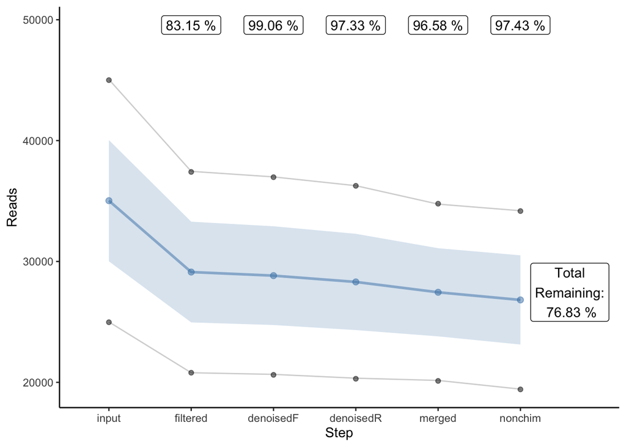

```r
# Plotting each sample's reads through the pipeline
track_plot <- track %>%
  pivot_longer(-Sample, names_to = "Step", values_to = "Reads") %>%
  mutate(Step = factor(Step,
                       levels = c("input", "filtered", "denoisedF", "denoisedR", "merged", "nonchim"))) %>%
  ggplot(aes(x = Step, y = Reads)) +
  geom_line(aes(group = Sample), alpha = 0.2) +
  geom_point(alpha = 0.5, position = position_jitter(width = 0)) +
  stat_summary(fun = median, geom = "line", group = 1, color = "steelblue", size = 1, alpha = 0.5) +
  stat_summary(fun = median, geom = "point", group = 1, color = "steelblue", size = 2, alpha = 0.5) +
  stat_summary(fun.data = median_hilow, fun.args = list(conf.int = 0.5),
               geom = "ribbon", group = 1, fill = "steelblue", alpha = 0.2) +
  geom_label(data = t(track_pct_avg[1:5]) %>% data.frame() %>%
               rename(Percent = 1) %>%
               mutate(Step = c("filtered", "denoisedF", "denoisedR", "merged", "nonchim"),
                      Percent = paste(round(Percent, 2), "%")),
             aes(label = Percent), y = 1.1 * max(track[,2])) +
  geom_label(data = track_pct_avg[6] %>% data.frame() %>%
               rename(total = 1),
             aes(label = paste("Total\nRemaining:\n", round(track_pct_avg[1,6], 2), "%")),
             y = mean(track[,6]), x = 6.6) +
  expand_limits(y = 1.1 * max(track[,2]), x = 7.2) +
  theme_classic()

track_plot
```